# PA1_template

Tania A.

## Data acquisition and pre-processing

The first step is to load the data. This was obtained from [the course website](https://www.coursera.org/learn/reproducible-research/peer/gYyPt/course-project-1)

```r
# loading the data
activity <- read.csv("activity.csv", header=T, quote="\"", sep=",")
```

Dropping NA’s and ensuring the dates are datetime class

```r
#saving a copy of the raw data
data_raw <- activity
data_raw$Dates <- as.Date(data_raw$date, "%Y-%m-%d")
# dropping NA
activity <- drop_na(activity)

# dates as date time class
activity$Dates <- as.Date(activity$date, "%Y-%m-%d")
```

## What is mean total number of steps taken per day?

1. Calculating the total number of steps per day
2. Plotting the obtained number of steps

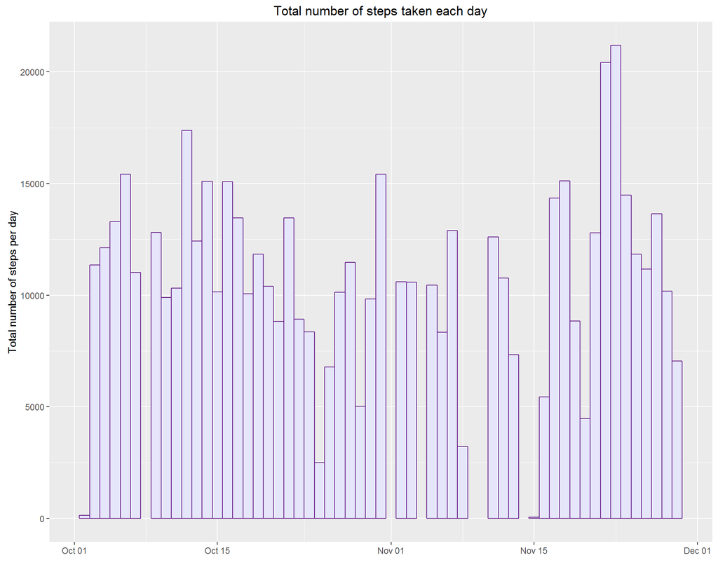

```r
# getting the total number of steps per day
steps_day <- summarise(group_by(activity, Dates), total_steps= sum(steps))

#plotting the data
p<-ggplot(data= steps_day, aes(x=Dates, y=total_steps))
p + geom_bar(width = 1.0, stat ='identity', colour='#68228B', fill='#E6E6FA') +
  xlab('')+ylab('Total number of steps per day') +
  ggtitle("Total number of steps taken each day") +
  theme(plot.title = element_text(hjust =0.5))
```

3. Now we need to calculate the mean and median number of steps per day

```r
#computing the mean steps per day
as.integer(mean(steps_day$total_steps))
```

```
## [1] 10766
```

```r
median(steps_day$total_steps)
```

```
## [1] 10765
```

The mean is *10766* and the median *10765*

# What is the average daily activity pattern?

1. Time series plot of the 5 minute interval (x) and the average number of steps taken averaged across all days (y)

```r
#group  by interval and find the mean steps
mean_steps_i <- summarise(group_by(activity, interval), mean_steps= mean(steps))
```

Plotting the time series

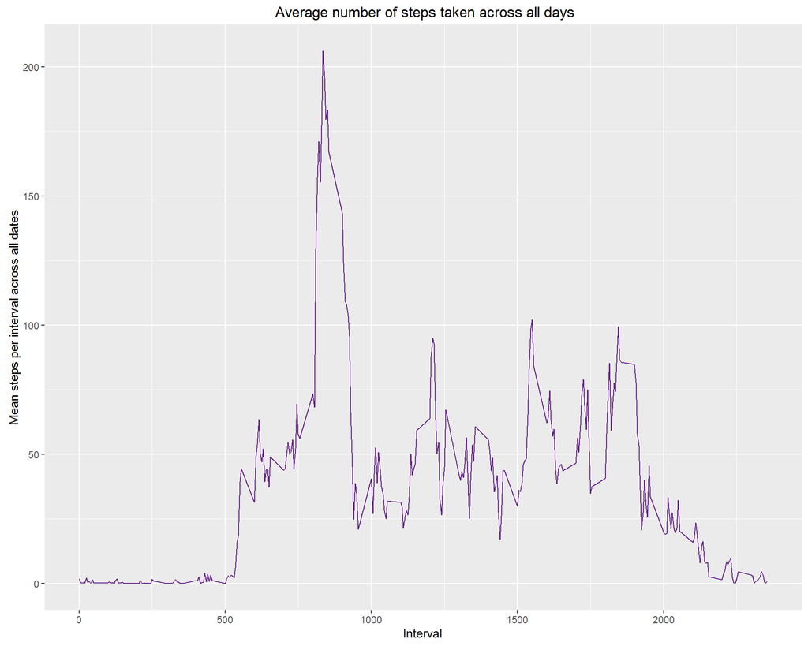

```r
p2<- ggplot(data = mean_steps_i, aes(x = interval, y = mean_steps))
p2 + geom_line(col= '#68228B') + xlab('Interval') +
  ylab('Mean steps per interval across all dates') +
  ggtitle( " Average number of steps taken across all days") +
  theme(plot.title = element_text(hjust = .5))
```

2. Getting the time intervals with the max number of steps per day

```r
# find the interval with the max number of steps
mean_steps_i[which.max(mean_steps_i$mean_steps),]
```

```
## # A tibble: 1 x 2
##   interval mean_steps
##      <int>      <dbl>
## 1      835   206.1698
```

## Imputing missing values

1. Calculating the number of NA’s

```r
# from the raw data
nrow(data_raw[!complete.cases(data_raw),])
```

```
## [1] 2304
```

The number of rows with NA was found to be *2304*

2. Devise a strategy to complete the missing values in the dataset.

As the mean data steps per time interval has already been computed before, we are going to use that data to fill in the missing values. This is done as follows:

- Loop over the raw data and find the NA’s
- Then look up the mean for that time interval in the previoulsy defined dataframe `mean_steps_i`

```r
dataFull <- data_raw
```

3. Completing the values in the dataframe, the completed data frame is `dataFull`

```r
for (i in 1:nrow(dataFull)){
  if (is.na(dataFull$steps[i])){
    interval_val <- dataFull$interval[i]
    row_id <- which(mean_steps_i$interval == interval_val)
    steps_val <- mean_steps_i$mean_steps[row_id]
    dataFull$steps[i] <- steps_val
  }
}
```

4. Create a histogram of the total number of steps taken each day using `dataFull`

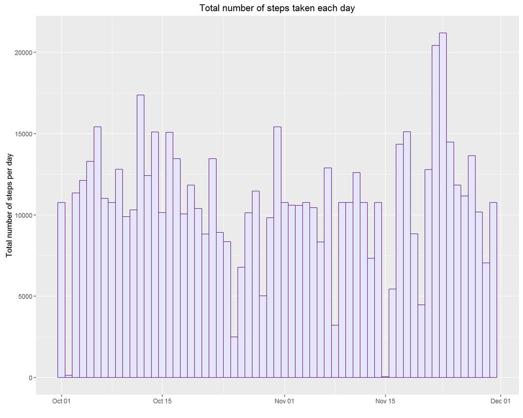

```r
# getting the total number of steps per day
steps_dayF <- summarise(group_by(dataFull, Dates), total_steps= sum(steps))

#plotting the data
p<-ggplot(data= steps_dayF, aes(x=Dates, y=total_steps))
p + geom_bar(width = 1.0, stat ='identity', colour='#68228B', fill='#E6E6FA') +
  xlab('')+ylab('Total number of steps per day') +
  ggtitle("Total number of steps taken each day") +
  theme(plot.title = element_text(hjust =0.5))
```

Now computing the mean and median and mean with the filled NA’s

```r
mean(steps_dayF$total_steps)
```

```
## [1] 10766.19
```

```r
median(steps_dayF$total_steps)
```

```
## [1] 10766.19
```

The mean and median of the data set with the replaced NA values well 10766, the mean presented no changes after adding the values while the median went from 10765 to 10766.

However when looking at the two histgrams presented is is evident that all the days corresponding to the period of time considered have now a total number of steps. As the values used for filling the NA’s was the mean value for each interval no major changes were expected to be observed when computing the mean of the steps per time interval.

# Are there differences in activity patterns between weekdays and weekends?

1. Create a factor variable to identify weekends and weekdays

```r
# creating the factor variable
dataFull$week<- as.factor(ifelse(weekdays(dataFull$Dates) %in% c("Saturday","Sunday"), "Weekend", "Weekday"))
# now finding the mean steps per interval
mean_steps_Fi<- aggregate(steps ~ interval + week, data = dataFull, mean)
```

2. Making a panel plot of the time series of the 5 minutes intervals and the mean steps taken across all wekeend days and weekdays

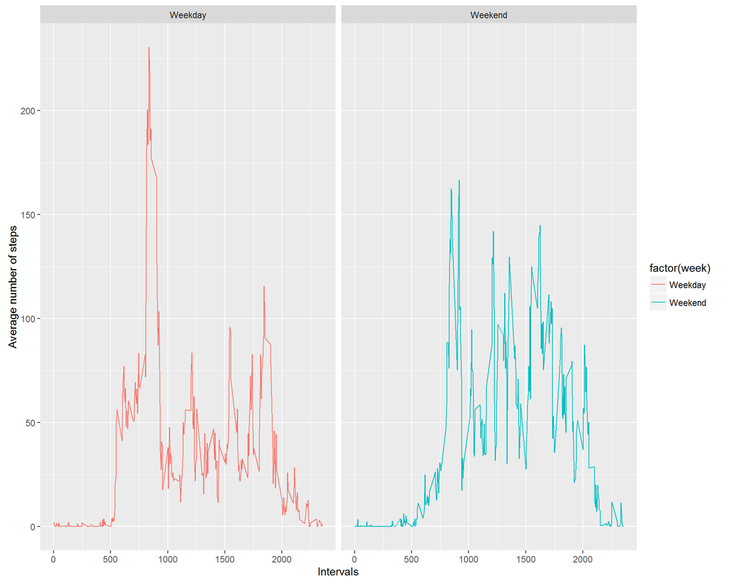

```r
p4<- ggplot(mean_steps_Fi, aes(interval, steps, colour = factor(week)))
p4 + geom_line() +facet_grid(.~ week) +
  xlab('Intervals') + ylab('Average number of steps')
```